# Dinâmica florestal com R

Géraldine Derroire & Sylvain Schmitt

Cirad

2025-11-07

## Pacotes R

Usaremos os pacotes `tidyverse` e `GGally` para manipular tabelas e criar gráficos, `vegan` para fazer análises da vegetação e `brms` e `tidybayes` para fazer modelização bayesiana.

```r
library(tidyverse)
library(GGally)
library(vegan)
library(brms)
library(tidybayes)
```

# Dados

## Dados de parcelas florestais permanentes

- Dados de uma parcela permanente (parcela 6) na estação de pesquisa florestal de [Paracou](https://paracou.cirad.fr/website) na Guiana Francesa
- Todas as árvores com um diâmetro à altura do peito (DAP) ≥ 10 cm são mapeadas, identificadas botanicamente e medidas em cada censo

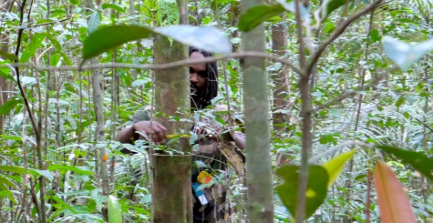

[figure not shown]

## Dados de parcelas florestais permanentes

Começamos carregando os dados na forma de objetos no formato Rdata.

```r
load("data/data_paracou_p6.RData")
dt_P6 <- dt_P6 %>%
  select(Forest, Plot, PlotArea, SubPlot,
         idTree, Xutm, Yutm,
         Family, Genus, Species,
         CensusYear, CodeAlive, CircCorr)
```

⚠️ Esses dados NÃO são de acesso livre, por favor, não os distribua nem utilize para qualquer outro fim.

## Dados de parcelas florestais permanentes

Esses dados contêm:

- **Forest**: Nome da floresta
- **Plot**: Número da parcela
- **PlotArea**: Área da parcela (hectares)
- **SubPlot**: Número da subparcela
- **idTree**: Identificador único da árvore no banco de dados
- **Xutm** e **Yutm**: Coordenadas da árvore (UTM 22N (EPSG: 32 622))
- **Family**
- **Genus**
- **Species**
- **CensusYear**: Ano da medição
- **CodeAlive**: A árvore está viva (1) ou morta (0)?
- **CircCorr**: Circunferência (cm) da árvore no ponto de medição

## Dados de características funcionais

Vamos usar os dados das características funcionais das árvores da Guiana Francesa obtidos na base de dados [TRY](https://www.try-db.org/TryWeb/Home.php) e compilados no pacote [rcontroll](https://besjournals.onlinelibrary.wiley.com/doi/full/10.1111/2041-210X.14215).

```r
dt_traits <- read_tsv("https://raw.githubusercontent.com/sylvainschmitt/rcontroll/refs/heads/main/inst/extdata/TROLLv3_species.txt") %>%
  select(-s_seedmass, -s_regionalfreq, -s_drymass) %>%
  rename(species = s_name, LMA = s_LMA, Nmass = s_Nmass,
         Pmass = s_Pmass, wsg = s_wsg, dbhmax = s_dbhmax,
         hmax = s_hmax, ah = s_ah, tlp = s_tlp)
dt_traits
```

```
# A tibble: 45 × 9
   species                     LMA  Nmass   Pmass   wsg dbhmax  hmax    ah   tlp
   <chr>                     <dbl>  <dbl>   <dbl> <dbl>  <dbl> <dbl> <dbl> <dbl>
 1 Abarema_jupunba           110.  0.0232 5.7 e-4 0.576   0.66  50.9 0.308 -1.60
 2 Bocoa_prouacensis          95.6 0.0255 5.05e-4 0.798   0.4   47.9 0.251 -2.08
 3 Brosimum_rubescens         85.8 0.0188 6.88e-4 0.619   0.52  50.9 0.308 -2.28
 4 Carapa_procera            130.  0.0177 6.36e-4 0.55    0.49  41.4 0.187 -1.93
 5 Caryocar_glabrum           84.2 0.0217 8.13e-4 0.612   1.15  48.6 0.275 -1.88
 6 Cecropia_obtusa            69.5 0.0276 1.38e-3 0.388   0.35  50.9 0.308 -1.43
 7 Chrysophyllum_sanguinole… 151.  0.0154 4.69e-4 0.566   0.67  50.9 0.308 -1.45
 8 Conceveiba_guianensis      86.7 0.0235 7.30e-4 0.537   0.23  33.3 0.16  -1.70
 9 Cordia_sagotii            134.  0.0253 5.92e-4 0.443   0.47  36.4 0.139 -1.91
10 Couepia_bracteosa         123.  0.015  4.82e-4 0.784   0.45  50.9 0.308 -2.26
# ℹ 35 more rows
```

## Dados de características funcionais

- massa foliar por área (**LMA**, em $g~m^{-2}$)
- massa de nitrogênio foliar (**Nmass**, em $g~g^{-1}$)
- massa de fósforo foliar (**Pmass**, em $g~g^{-1}$)
- gravidade específica da madeira (**wsg**, em $g~cm^{-3}$)
- potencial hídrico foliar no ponto de perda de turgor (**tlp**, em $MPa$)

```r
dt_traits <- dt_traits %>%
  select(species, LMA, Nmass, Pmass, wsg, tlp)

dt_traits %>% slice_head(n = 5)
```

```
# A tibble: 5 × 6
  species              LMA  Nmass    Pmass   wsg   tlp
  <chr>              <dbl>  <dbl>    <dbl> <dbl> <dbl>
1 Abarema_jupunba    110.  0.0232 0.00057  0.576 -1.60
2 Bocoa_prouacensis   95.6 0.0255 0.000505 0.798 -2.08
3 Brosimum_rubescens  85.8 0.0188 0.000688 0.619 -2.28
4 Carapa_procera     130.  0.0177 0.000636 0.55  -1.93
5 Caryocar_glabrum    84.2 0.0217 0.000813 0.612 -1.88
```

# Exploração de dados de características funcionais

## Distribuição das valores das características

Podemos começar examinando a distribuição de valores para cada um dos recursos com um histograma usando o pacote `ggplot` (parte de `tidyverse`).

```r
dt_traits %>%
  pivot_longer(LMA : tlp,
               names_to = "traits", values_to = "values") %>%
  ggplot(aes(x = values)) + geom_histogram() +
  facet_wrap(~ traits, scales = "free") + theme_bw()
```

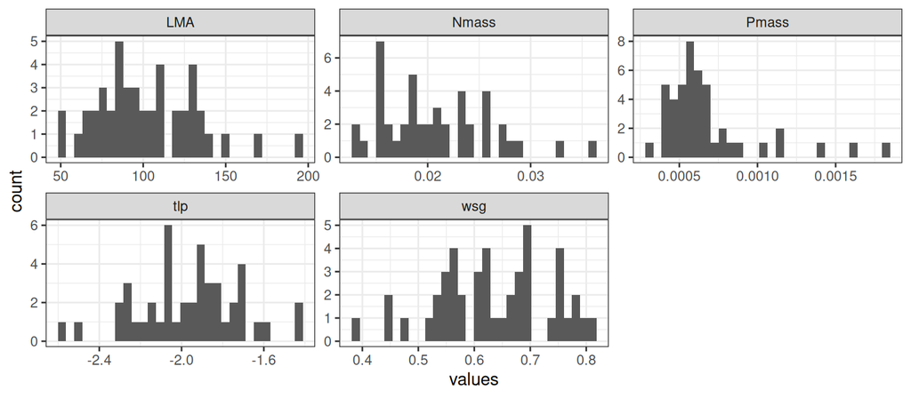

## Coeficientes de variação das características

Podemos ver que as características são mais ou menos variáveis, mas para quantificar isso adequadamente, podemos usar o coeficiente de variação definido como:

$$CV = \frac{desvio\ padrão}{média}$$

```r
dt_traits %>% summarise(
  across(LMA : tlp,
         function(v) {round(sd(v)/abs(mean(v)), 3)}))
```

```
# A tibble: 1 × 5
    LMA Nmass Pmass   wsg   tlp
  <dbl> <dbl> <dbl> <dbl> <dbl>
1 0.295 0.253 0.455 0.161 0.127
```

## Correlações entre pares de características

As características não variam de forma independente, portanto, podemos explorar as relações entre cada par de características usando os coeficientes de correlação.

```r
ggpairs(dt_traits, columns = names(dt_traits)[-1])
```

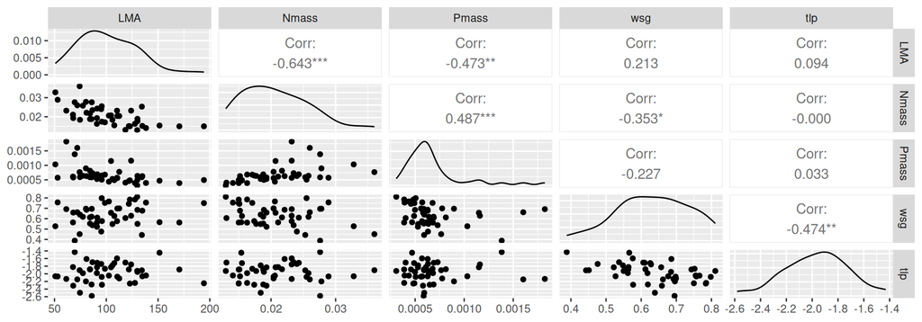

## Axes de covariância de características funcionais

Para entender melhor a organização geral de todos os recursos em “estratégias funcionais”, podemos construir uma análise de componentes principais (ACP) com o pacote `vegan`.

```r
trait_pca <- dt_traits %>% select(-species) %>%
  pca(scale = TRUE)
summary(trait_pca)
```

```
Call:
pca(X = ., scale = TRUE)

Partitioning of correlations:
              Inertia Proportion
Total               5          1
Unconstrained       5          1

Eigenvalues, and their contribution to the correlations

Importance of components:
                         PC1    PC2    PC3     PC4     PC5
Eigenvalue            2.2584 1.3822 0.5916 0.43239 0.33541
Proportion Explained  0.4517 0.2764 0.1183 0.08648 0.06708
Cumulative Proportion 0.4517 0.7281 0.8464 0.93292 1.00000
```

## Axes de covariância de características funcionais

Podemos representar a PCA em um biplot de eixos 1-2 com as características como variáveis representadas por setas e as espécies por pontos posicionados de acordo com os valores de suas características.

```r
# display as características
biplot(trait_pca, scaling = 2,
       display = "species")
# display as espécies
points(trait_pca, scaling = 2,
       display = "sites", type ="points")
```

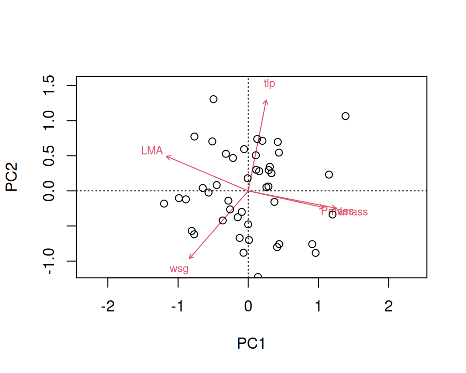

- Axe 1: **espectro econômico das folhas**: estratégias de aquisição de recursos conservadoras (lentas) *versus* aquisitivas (rápidas) [Wright *et al* 2004](https://www.nature.com/articles/nature02403)
- As características da madeira [Baraloto *et al* 2010](https://onlinelibrary.wiley.com/doi/10.1111/j.1461-0248.2010.01517.x) e as características relacionadas com a água [Maréchaux *et al* 2019](https://besjournals.onlinelibrary.wiley.com/doi/full/10.1111/1365-2745.13321) são independentes do espectro econômico das folhas.

# Exploração dos dados de crescimento

## Preparação dos dados

Para usar os dados de crescimento, começamos filtrando os dados da parcela 6.

- Manter apenas as árvores totalmente determinadas

```r
dt_P6 <- dt_P6 %>%
  filter(Species != "Indet.")
```

- Calcular o DAP

```r
dt_P6 <- dt_P6 %>%
  mutate(DBH = CircCorr / pi)
```

- Manter apenas a observação de árvores vivas com $DAP ≥ 10 cm$

```r
dt_P6 <- dt_P6 %>%
  filter(DBH >= 10 & CodeAlive ==1)
```

- Adicionar os nomes completos das espécies

```r
dt_P6 <- dt_P6 %>%
  unite(GenSp,
        Genus, Species,
        sep = "_",
        remove = FALSE)
```

## Número de indivíduos

- Número total de indivíduos

```r
n_distinct(dt_P6$idTree)
```

```
[1] 4262
```

- Número de indivíduos por censo e duração do monitoramento

```r
dt_P6 %>% count(CensusYear)  %>%
  ggplot(aes(x = CensusYear, y = n)) +
  geom_point() + geom_line() +
  ylim(0, 4000) +
  labs(x = "Ano da medição", y = "Número de indivíduos") +
  theme_bw()
```

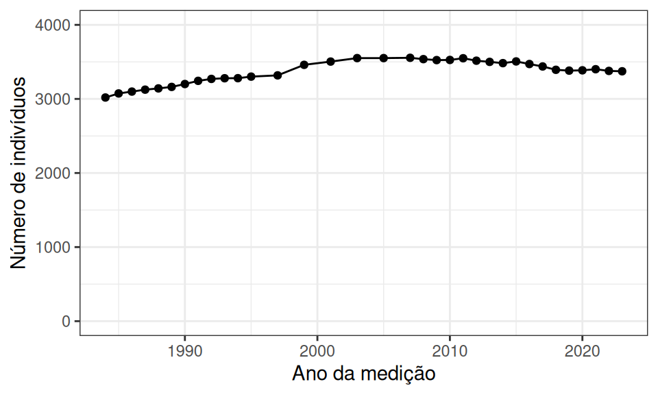

## Cálculo do crescimento anual

```r
dt_P6 <- dt_P6 %>%
  group_by(idTree) %>%
  arrange(CensusYear) %>%
  mutate(Growth = (DBH - lag(DBH)) / (CensusYear - lag(CensusYear))) %>%
  filter(Growth >= 0) %>%
  ungroup()

dt_P6 %>% select(idTree, CensusYear, DBH, Growth) %>%
  filter(idTree == 100621) %>%
  head(n = 15)
```

```
# A tibble: 15 × 4
   idTree CensusYear   DBH Growth
    <dbl>      <dbl> <dbl>  <dbl>
 1 100621       1985  12.7 0
 2 100621       1986  12.7 0
 3 100621       1987  12.9 0.159
 4 100621       1988  12.9 0
 5 100621       1989  13.2 0.318
 6 100621       1991  12.9 0
 7 100621       1992  12.9 0
 8 100621       1993  13.1 0.159
 9 100621       1994  13.2 0.159
10 100621       1997  13.1 0
11 100621       1999  13.2 0.0796
12 100621       2001  13.2 0
13 100621       2003  13.2 0
14 100621       2005  13.2 0
15 100621       2007  13.2 0
```

## Trajetórias de crescimento

```r
plot_traj_DBH <- function(id, dt) {
    sp <- dt %>% filter(idTree == id) %>% distinct(GenSp) # especie
    n <- dt %>% filter(idTree == id) %>% count() # medições
    filter(dt, idTree == id) %>%
      ggplot(aes(x=CensusYear, y = DBH)) +
      geom_point() +
      geom_smooth(method = "loess", se = FALSE) +
      labs(x = "Ano da medição",
           y = "Diâmetro à altura do peito (em cm)",
           title = paste0("Trajetória do diâmetro - Indivíduo ", id,
                          " - ", sp, " (", n, " medições)")) + theme_bw()
}
plot_traj_DBH(id = "103768", dt = dt_P6)
```

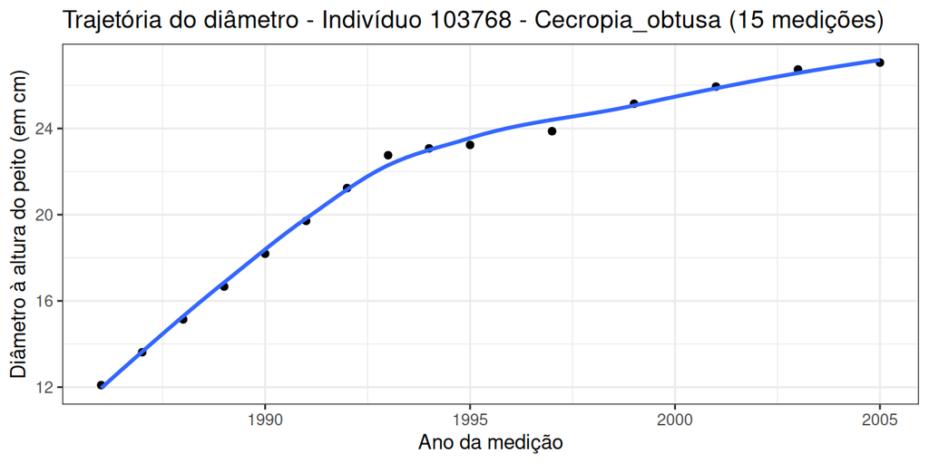

## Trajetórias de crescimento

```r
plot_traj_Growth <- function(id, dt) {
    sp <- dt %>% filter(idTree == id) %>% distinct(GenSp) # especie
    n <- dt %>% filter(idTree == id) %>% count() # medições
    filter(dt, idTree == id) %>%
      ggplot(aes(x=DBH, y = Growth)) +
      geom_point() +
      geom_smooth(method = "loess", se = FALSE) +
      labs(x = "Ano da medição",
           y = "Crescimento anual (em cm/ano)",
           title = paste0("Trajetória de crecimento - Indivíduo ", id,
                          " - ", sp, " (", n, " medições)")) + theme_bw()
}
plot_traj_Growth(id = "103768", dt = dt_P6)
```

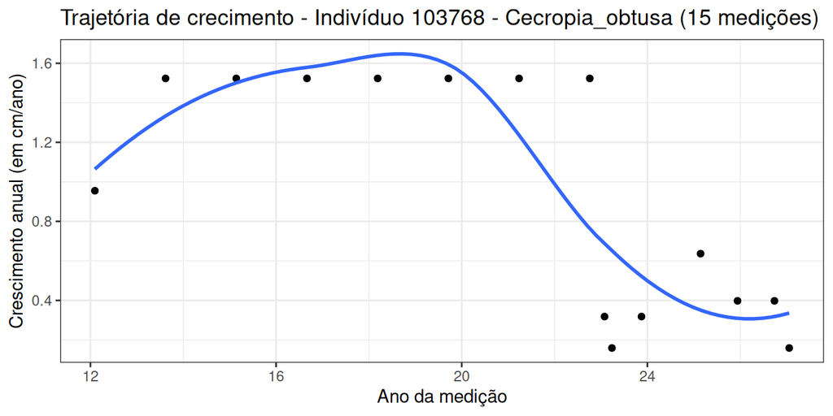

## Trajetórias de crescimento

```r
plot_traj_sp <- function(sp, dt) {
    n <- dt %>% filter(GenSp == sp) %>% count() # medições
    filter(dt, GenSp == sp) %>%
      ggplot(aes(x=DBH, y = Growth)) +
      geom_point() +
      geom_smooth(method = "loess", se = FALSE) +
      labs(x = "Diâmetro à altura do peito (em cm)",
           y = "Crescimento anual (em cm/ano)",
           title = paste0("Trajetória de crecimento - ",
                          sp, " (", n, " medições)")) + theme_bw()
}
plot_traj_sp(sp = "Cecropia_obtusa", dt = dt_P6)
```

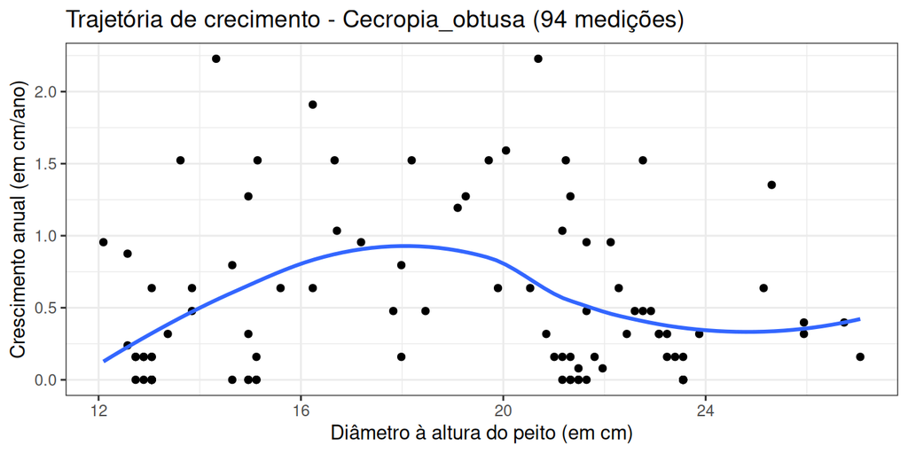

# Modelagem do crescimento

## Modelo de Canham

$$log(AGR+1)=G \times exp[-0.5 \times( \frac{log(DBH/D)}{K}^2)]$$

```r
data_frame(DBH = 10:100) %>% mutate(log_agr = 0.5*exp(-0.5*(log(DBH/50)^2/0.2))) %>%
  ggplot(aes(DBH, exp(log_agr)-1)) + geom_line() + theme_bw() +
  labs(x = "Diâmetro à altura do peito",
       y = "Crescimento anual") + theme_bw() +
  geom_vline(xintercept = 50, colour = "red", linetype = "dashed") +
  geom_hline(yintercept = exp(0.5)-1, colour = "red", linetype = "dashed")
```

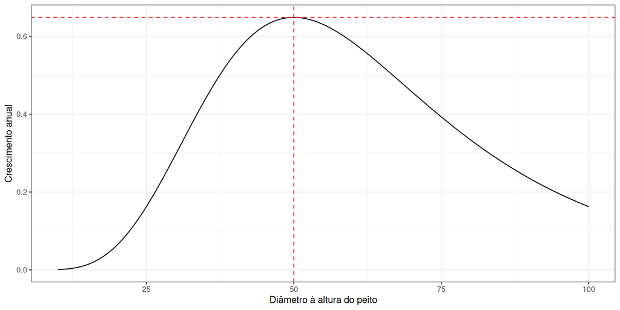

## Uma inferência com *Cecropia obtusa*

```r
fit <- brm(bf(log(Growth+1) ~ G*exp(-0.5*(log(DBH/D)^2/K)),
              G ~ 1, D ~ 1, K ~ 1,
              nl = TRUE),
           prior = c(
                 prior("uniform(0.001,3)", lb = 0.001, ub = 3, nlpar = "G"),
                 prior("uniform(0.001,3)", lb = 0.001, ub = 3, nlpar = "K"),
                 prior("uniform(1,30)", lb = 1, ub = 30, nlpar = "D")
          ),
           data = filter(dt_P6, GenSp  == "Cecropia_obtusa"),
           cores = 4)
save(fit, file = "data/fit_cecro.Rdata")
```

```r
load(file = "data/fit_cecro.Rdata") ; fit
```

```
 Family: gaussian
  Links: mu = identity; sigma = identity
Formula: log(Growth + 1) ~ G * exp(-0.5 * (log(DBH/D)^2/K))
         G ~ 1
         D ~ 1
         K ~ 1
   Data: filter(dt_P6, GenSp == "Cecropia_obtusa") (Number of observations: 94)
  Draws: 4 chains, each with iter = 2000; warmup = 1000; thin = 1;
         total post-warmup draws = 4000

Regression Coefficients:
            Estimate Est.Error l-95% CI u-95% CI Rhat Bulk_ESS Tail_ESS
G_Intercept     0.44      0.10     0.31     0.67 1.05       76      319
D_Intercept    18.79      4.67     8.26    28.51 1.04      712      773
K_Intercept     0.98      0.97     0.04     2.89 1.05       85      476

Further Distributional Parameters:
      Estimate Est.Error l-95% CI u-95% CI Rhat Bulk_ESS Tail_ESS
sigma     0.33      0.03     0.29     0.39 1.02      410      724

Draws were sampled using sampling(NUTS). For each parameter, Bulk_ESS
and Tail_ESS are effective sample size measures, and Rhat is the potential
scale reduction factor on split chains (at convergence, Rhat = 1).
```

## Uma inferência com *Cecropia obtusa*

```r
plot_fit <- function(fit, Species) {
  G <- posterior_summary(fit)[1, "Estimate"]
  D <- posterior_summary(fit)[2, "Estimate"]
  K <- posterior_summary(fit)[3, "Estimate"]
  filter(dt_P6, GenSp  == !!Species) %>%
    ggplot(aes(x=DBH, y = Growth)) + geom_point() +
    stat_function(fun = function(x) exp(G*exp(-0.5*(log(x/D)^2/K))) - 1,
                  colour = "red", size = 2) +
        labs(x = "Diâmetro à altura do peito (em cm)",
             y = "Crescimento anual (em cm/ano)") + theme_bw() +
    geom_vline(xintercept = D, colour = "red", linetype = "dashed") +
    geom_hline(yintercept = exp(G)-1, colour = "red", linetype = "dashed") +
    ylim(0, NA) + xlim(10, NA)
}
```

## Uma inferência com *Cecropia obtusa*

```r
plot_fit(fit = fit, Species = "Cecropia_obtusa")
```

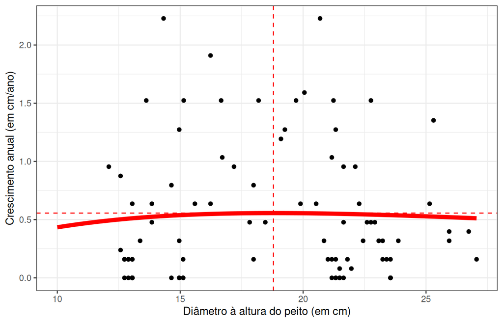

## Uma inferência com *Dicorynia guianensis*

```r
fit <- brm(bf(log(Growth+1) ~ G*exp(-0.5*(log(DBH/D)^2/K)),
              G ~ 1, D ~ 1, K ~ 1,
              nl = TRUE),
           prior = c(
                 prior("uniform(0.001,3)", lb = 0.001, ub = 3, nlpar = "G"),
                 prior("uniform(0.001,3)", lb = 0.001, ub = 3, nlpar = "K"),
                 prior("uniform(1,300)", lb = 1, ub = 300, nlpar = "D")
          ),
           data = filter(dt_P6, GenSp  == "Dicorynia_guianensis"),
           cores = 4)
save(fit, file = "data/fit_dico.Rdata")
```

```r
load(file = "data/fit_dico.Rdata") ; fit
```

```
 Family: gaussian
  Links: mu = identity; sigma = identity
Formula: log(Growth + 1) ~ G * exp(-0.5 * (log(DBH/D)^2/K))
         G ~ 1
         D ~ 1
         K ~ 1
   Data: filter(dt_P6, GenSp == "Dicorynia_guianensis") (Number of observations: 1268)
  Draws: 4 chains, each with iter = 2000; warmup = 1000; thin = 1;
         total post-warmup draws = 4000

Regression Coefficients:
            Estimate Est.Error l-95% CI u-95% CI Rhat Bulk_ESS Tail_ESS
G_Intercept     0.29      0.01     0.27     0.30 1.00     1923     2082
D_Intercept    33.79      1.35    31.39    36.79 1.00     2223     2076
K_Intercept     0.63      0.08     0.49     0.81 1.00     1784     2086

Further Distributional Parameters:
      Estimate Est.Error l-95% CI u-95% CI Rhat Bulk_ESS Tail_ESS
sigma     0.18      0.00     0.17     0.18 1.00     3111     2469

Draws were sampled using sampling(NUTS). For each parameter, Bulk_ESS
and Tail_ESS are effective sample size measures, and Rhat is the potential
scale reduction factor on split chains (at convergence, Rhat = 1).
```

## Uma inferência com *Dicorynia guianensis*

```r
plot_fit(fit = fit, Species = "Dicorynia_guianensis")
```

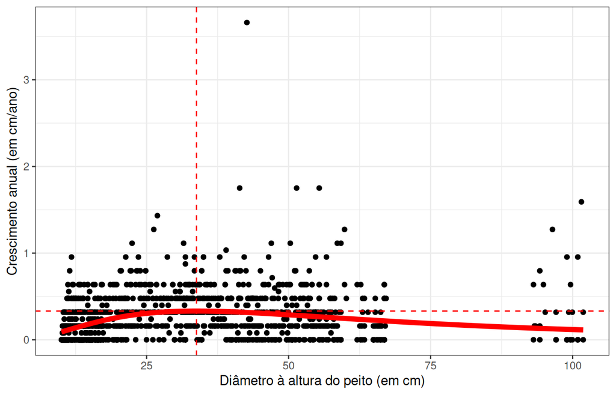

## Uma inferência com *Eschweilera sagotiana*

```r
fit <- brm(bf(log(Growth+1) ~ G*exp(-0.5*(log(DBH/D)^2/K)),
              G ~ 1, D ~ 1, K ~ 1,
              nl = TRUE),
           prior = c(
                 prior("uniform(0.001,3)", lb = 0.001, ub = 3, nlpar = "G"),
                 prior("uniform(0.001,3)", lb = 0.001, ub = 3, nlpar = "K"),
                 prior("uniform(1,300)", lb = 1, ub = 300, nlpar = "D")
          ),
           data = filter(dt_P6, GenSp  == "Eschweilera_sagotiana"),
           cores = 4)
save(fit, file = "data/fit_esch.Rdata")
```

```r
load(file = "data/fit_esch.Rdata") ; fit
```

```
 Family: gaussian
  Links: mu = identity; sigma = identity
Formula: log(Growth + 1) ~ G * exp(-0.5 * (log(DBH/D)^2/K))
         G ~ 1
         D ~ 1
         K ~ 1
   Data: filter(dt_P6, GenSp == "Eschweilera_sagotiana") (Number of observations: 4529)
  Draws: 4 chains, each with iter = 2000; warmup = 1000; thin = 1;
         total post-warmup draws = 4000

Regression Coefficients:
            Estimate Est.Error l-95% CI u-95% CI Rhat Bulk_ESS Tail_ESS
G_Intercept     0.10      0.00     0.10     0.11 1.00     3517     2751
D_Intercept    27.59      3.86    20.89    35.84 1.00     3210     2336
K_Intercept     2.77      0.20     2.24     2.99 1.00     3095     1694

Further Distributional Parameters:
      Estimate Est.Error l-95% CI u-95% CI Rhat Bulk_ESS Tail_ESS
sigma     0.13      0.00     0.13     0.13 1.00     4203     2866

Draws were sampled using sampling(NUTS). For each parameter, Bulk_ESS
and Tail_ESS are effective sample size measures, and Rhat is the potential
scale reduction factor on split chains (at convergence, Rhat = 1).
```

## Uma inferência com *Eschweilera sagotiana*

```r
plot_fit(fit = fit, Species = "Eschweilera_sagotiana")
```

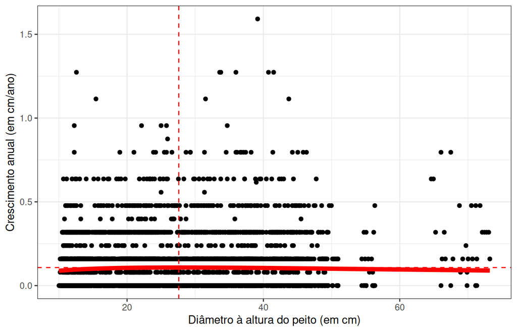

## Modelo de crescimento individual

$$log(AGR+1)= G_{tree} \times exp[-0.5 \times( \frac{log(DBH/D)^2}{K})] ~~|~~G_{tree} = G_{species}+\epsilon_{tree}$$

```r
expand_grid(DBH = 10:100, G_tree = rnorm(10, 0.5, 0.1)) %>%
  mutate(log_agr = G_tree*exp(-0.5*(log(DBH/50)^2/0.2))) %>%
  ggplot(aes(DBH, exp(log_agr)-1,
             group = as.character(G_tree))) + geom_line() + theme_bw() +
  labs(x = "Diâmetro à altura do peito",
       y = "Crescimento anual") + theme_bw() +
  geom_vline(xintercept = 50, colour = "red", linetype = "dashed") +
  geom_hline(yintercept = exp(0.5)-1, colour = "red", linetype = "dashed")
```

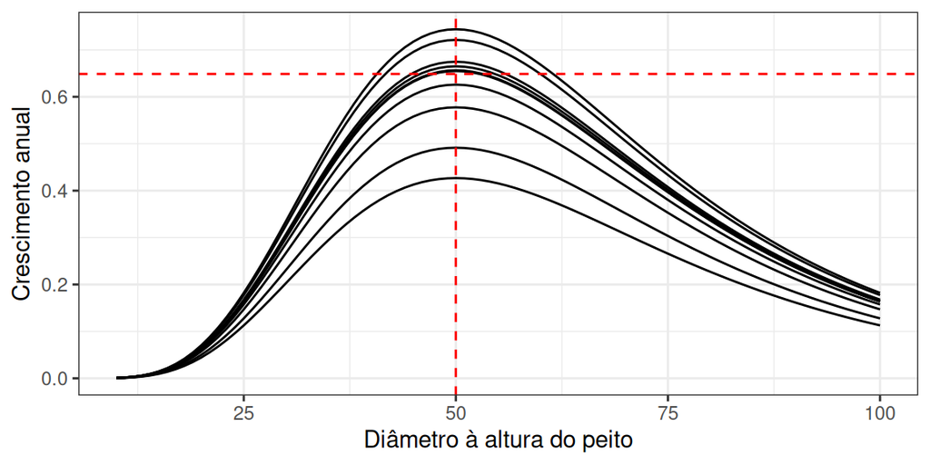

## Modelo de crescimento individual

```r
fit <- brm(bf(log(Growth+1) ~ G*exp(-0.5*(log(DBH/D)^2/K)),
              G ~ 1|idTree, D ~ 1, K ~ 1,
              nl = TRUE),
           prior = c(
                 prior("uniform(0.001,3)", lb = 0.001, ub = 3, nlpar = "G"),
                 prior("uniform(0.001,3)", lb = 0.001, ub = 3, nlpar = "K"),
                 prior("uniform(1,300)", lb = 1, ub = 300, nlpar = "D")
          ),
           data = filter(dt_P6, GenSp  == "Dicorynia_guianensis"),
           cores = 4)
save(fit, file = "data/fit_dico_ind.Rdata")
```

```r
load(file = "data/fit_dico_ind.Rdata") ; fit
```

```
 Family: gaussian
  Links: mu = identity; sigma = identity
Formula: log(Growth + 1) ~ G * exp(-0.5 * (log(DBH/D)^2/K))
         G ~ 1 | idTree
         D ~ 1
         K ~ 1
   Data: filter(dt_P6, GenSp == "Dicorynia_guianensis") (Number of observations: 1268)
  Draws: 4 chains, each with iter = 2000; warmup = 1000; thin = 1;
         total post-warmup draws = 4000

Multilevel Hyperparameters:
~idTree (Number of levels: 51)
                Estimate Est.Error l-95% CI u-95% CI Rhat Bulk_ESS Tail_ESS
sd(G_Intercept)     0.10      0.01     0.07     0.12 1.00      919     1323

Regression Coefficients:
            Estimate Est.Error l-95% CI u-95% CI Rhat Bulk_ESS Tail_ESS
G_Intercept     0.24      0.02     0.20     0.28 1.01      847     1453
D_Intercept    44.42     11.57    29.93    74.56 1.00     1402     1610
K_Intercept     2.04      0.57     1.01     2.96 1.00     1374     1767

Further Distributional Parameters:
      Estimate Est.Error l-95% CI u-95% CI Rhat Bulk_ESS Tail_ESS
sigma     0.16      0.00     0.16     0.17 1.00     4040     2744

Draws were sampled using sampling(NUTS). For each parameter, Bulk_ESS
and Tail_ESS are effective sample size measures, and Rhat is the potential
scale reduction factor on split chains (at convergence, Rhat = 1).
```

## Modelo de crescimento individual

```r
fit %>%
  spread_draws(b_G_Intercept, r_idTree__G[idTree,]) %>%
  mutate(G_tree = exp(b_G_Intercept + r_idTree__G) - 1) %>%
  group_by(idTree) %>%
  summarise(G_tree = median(G_tree)) %>%
  ggplot(aes(G_tree)) + geom_histogram() + theme_bw() +
  labs(x = "Crescimento individual (em cm/ano)")
```

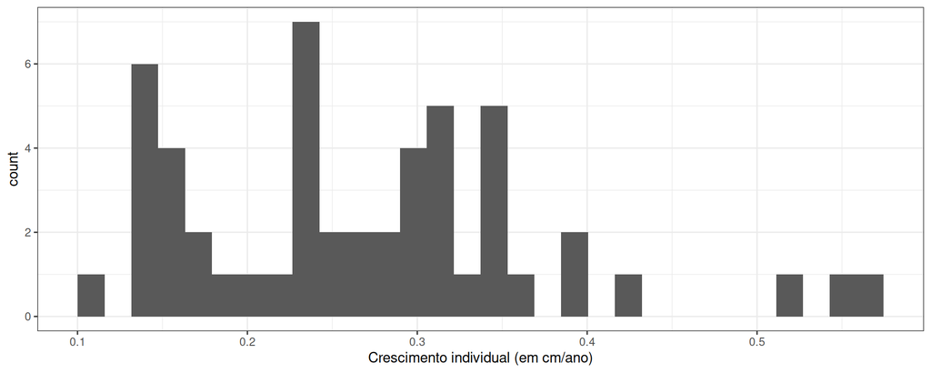

# Usar características funcionais para explicar o crescimento

## Distribuição das crescimentos

Começamos recuperando todos os crescimentos das espécies de Paracou disponíveis em [Schmitt, Hérault, Derroire (2023)](https://onlinelibrary.wiley.com/doi/full/10.1111/ele.14318), e selecionamos as espécies para as quais temos valores de características

```r
dt <- read_csv("data/growth_raw.csv", locale = locale(decimal_mark = ",")) %>%
  select(Species, `Median Gmax`) %>%
  rename(species = Species, Gmax =  `Median Gmax`) %>%
  mutate(species = gsub(" ", "_", species)) %>%
  right_join(dt_traits) %>%
  filter(Gmax < 3)
dt %>% ggplot(aes(Gmax)) + geom_histogram() + theme_bw() + scale_x_log10()
```

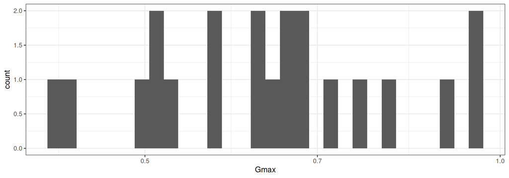

## Correlações entre características e crescimento

```r
ggpairs(dt, columns = c("Gmax", "LMA", "wsg"))
```

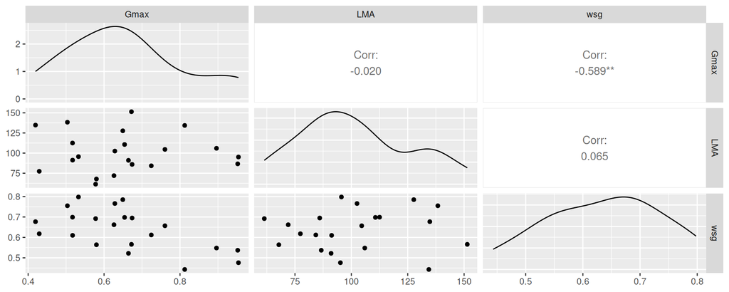

## Regressão linear

Também podemos usar a regressão linear para identificar estratégias relacionadas ao crescimento das espécies.

```r
lm(Gmax ~ LMA + wsg, dt) %>%
  summary()
```

```
Call:
lm(formula = Gmax ~ LMA + wsg, data = dt)

Residuals:
      Min        1Q    Median        3Q       Max
-0.239838 -0.082860 -0.002604  0.090345  0.208692

Coefficients:
              Estimate Std. Error t value Pr(>|t|)
(Intercept)  1.2191956  0.2169689   5.619 2.48e-05 ***
LMA          0.0001114  0.0011878   0.094  0.92633
wsg         -0.9041136  0.2920908  -3.095  0.00624 **
---
Signif. codes:  0 '***' 0.001 '**' 0.01 '*' 0.05 '.' 0.1 ' ' 1

Residual standard error: 0.1309 on 18 degrees of freedom
Multiple R-squared:  0.3476,    Adjusted R-squared:  0.2752
F-statistic: 4.796 on 2 and 18 DF,  p-value: 0.0214
```

# Conclusão

Parabéns 👏 , agora vocês são profissionais do modelagem do crescimento!

Falando mais seriamente, ficaremos felizes em responder a quaisquer perguntas que você possa ter.

*Sylvain Schmitt (sylvain.schmitt@cirad.fr) & Géraldine Derroire (geraldine.derroire@cirad.fr)*